# White Wine Quality

Cynthia O’Donnell

06/24/2015

In this exploratory data analysis I will determine which chemical properties influence the quality of white wines.

### General Information

This dataset is comprised of data regarding chemical properties of Vinho Verde wine, the white variety. Vinho Verde is a slightly sparkling, Portuguese wine that is relatively rare in America. The wine is made from one of several different types of Portugese grape varieties or, more commonly, from a blend of many of them.

The name means “green wine”, which refers to the fact that the grapes are not fully ripe when picked and also not aged. This contributes to the high acidity for which Vinho Verde is known. These wines are meant to be consumed within a year of bottling.

More recently, higher alcohol varieties of Vinho Verde have been produced. These wines, while relatively rare, are also less acidic and not sparkling.

The general information regarding these wines is that those in the 9-10% alcohol range are cheap, semi-sparkling and refreshing, while those in the 12% and above range are considered serious wines that sell for several times the amount of the cheaper, lower alcohol varieties.

From this, I can gather that alcohol content is an important factor as would be the acidity levels generally.

References for this section can be found at the end of this analysis.

### Read Data

```r
wine = read.csv('wineQualityWhites.csv')
names(wine)
```

```
##  [1] "X"                    "fixed.acidity"        "volatile.acidity"
##  [4] "citric.acid"          "residual.sugar"       "chlorides"
##  [7] "free.sulfur.dioxide"  "total.sulfur.dioxide" "density"
## [10] "pH"                   "sulphates"            "alcohol"
## [13] "quality"
```

```r
# Remove the X variable because it is just the index number
wine$X = NULL
```

### Structure of the Data

```r
str(wine)
```

```
## 'data.frame':    4898 obs. of  12 variables:
##  $ fixed.acidity       : num  7 6.3 8.1 7.2 7.2 8.1 6.2 7 6.3 8.1 ...
##  $ volatile.acidity    : num  0.27 0.3 0.28 0.23 0.23 0.28 0.32 0.27 0.3 0.22 ...
##  $ citric.acid         : num  0.36 0.34 0.4 0.32 0.32 0.4 0.16 0.36 0.34 0.43 ...
##  $ residual.sugar      : num  20.7 1.6 6.9 8.5 8.5 6.9 7 20.7 1.6 1.5 ...
##  $ chlorides           : num  0.045 0.049 0.05 0.058 0.058 0.05 0.045 0.045 0.049 0.044 ...
##  $ free.sulfur.dioxide : num  45 14 30 47 47 30 30 45 14 28 ...
##  $ total.sulfur.dioxide: num  170 132 97 186 186 97 136 170 132 129 ...
##  $ density             : num  1.001 0.994 0.995 0.996 0.996 ...
##  $ pH                  : num  3 3.3 3.26 3.19 3.19 3.26 3.18 3 3.3 3.22 ...
##  $ sulphates           : num  0.45 0.49 0.44 0.4 0.4 0.44 0.47 0.45 0.49 0.45 ...
##  $ alcohol             : num  8.8 9.5 10.1 9.9 9.9 10.1 9.6 8.8 9.5 11 ...
##  $ quality             : int  6 6 6 6 6 6 6 6 6 6 ...
```

All of the variables are either numeric or integer. Let’s explore the ranges and distributions of the variables.

# Univariate Analysis

The quality of wine is outcome variable so I will examine it first.

### Plot Quality Histogram

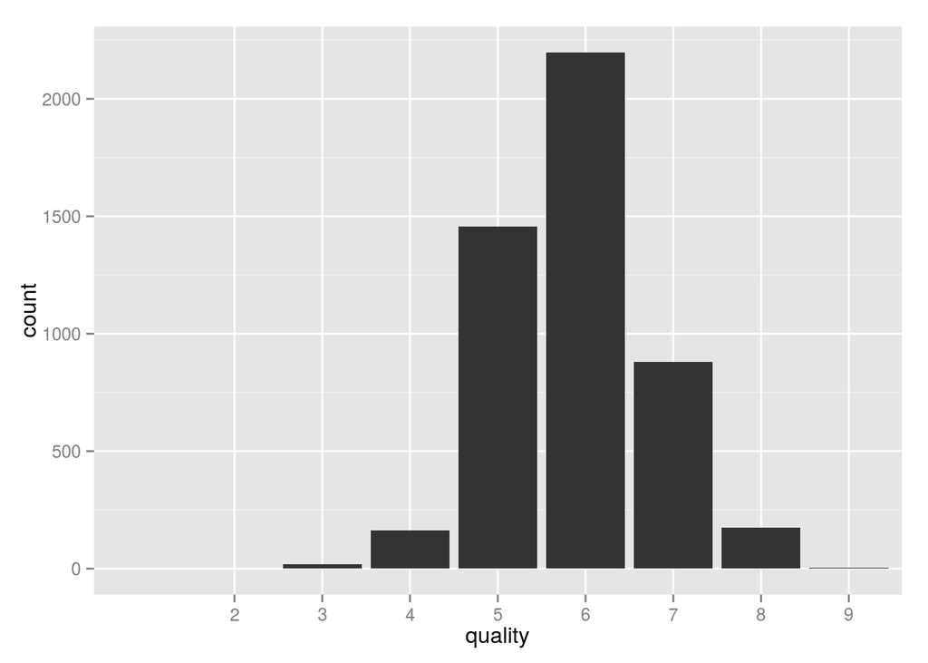

```r
qplot(quality, data=wine) +
  scale_x_discrete(breaks=0:10)
```

This is a fairly normal distribution with many most wines ranked as 5 or 6.

### Summarize Data

```r
summary(wine)
```

```
##  fixed.acidity    volatile.acidity  citric.acid     residual.sugar
##  Min.   : 3.800   Min.   :0.0800   Min.   :0.0000   Min.   : 0.600
##  1st Qu.: 6.300   1st Qu.:0.2100   1st Qu.:0.2700   1st Qu.: 1.700
##  Median : 6.800   Median :0.2600   Median :0.3200   Median : 5.200
##  Mean   : 6.855   Mean   :0.2782   Mean   :0.3342   Mean   : 6.391
##  3rd Qu.: 7.300   3rd Qu.:0.3200   3rd Qu.:0.3900   3rd Qu.: 9.900
##  Max.   :14.200   Max.   :1.1000   Max.   :1.6600   Max.   :65.800
##    chlorides       free.sulfur.dioxide total.sulfur.dioxide
##  Min.   :0.00900   Min.   :  2.00      Min.   :  9.0
##  1st Qu.:0.03600   1st Qu.: 23.00      1st Qu.:108.0
##  Median :0.04300   Median : 34.00      Median :134.0
##  Mean   :0.04577   Mean   : 35.31      Mean   :138.4
##  3rd Qu.:0.05000   3rd Qu.: 46.00      3rd Qu.:167.0
##  Max.   :0.34600   Max.   :289.00      Max.   :440.0
##     density             pH          sulphates         alcohol
##  Min.   :0.9871   Min.   :2.720   Min.   :0.2200   Min.   : 8.00
##  1st Qu.:0.9917   1st Qu.:3.090   1st Qu.:0.4100   1st Qu.: 9.50
##  Median :0.9937   Median :3.180   Median :0.4700   Median :10.40
##  Mean   :0.9940   Mean   :3.188   Mean   :0.4898   Mean   :10.51
##  3rd Qu.:0.9961   3rd Qu.:3.280   3rd Qu.:0.5500   3rd Qu.:11.40
##  Max.   :1.0390   Max.   :3.820   Max.   :1.0800   Max.   :14.20
##     quality
##  Min.   :3.000
##  1st Qu.:5.000
##  Median :6.000
##  Mean   :5.878
##  3rd Qu.:6.000
##  Max.   :9.000
```

The information regarding the variables states that scale of wine quality is from 0 to 10. However, the range of wine qualities in this dataset is 3 to 9. The mean is 5.878 and the median is 6.

Many of the other variables have fairly extreme outliers on the higher end of scale, frequently a multiple of the 3rd quartile value.

Let’s view the distributions of all of the variables.

### All Variable Histograms

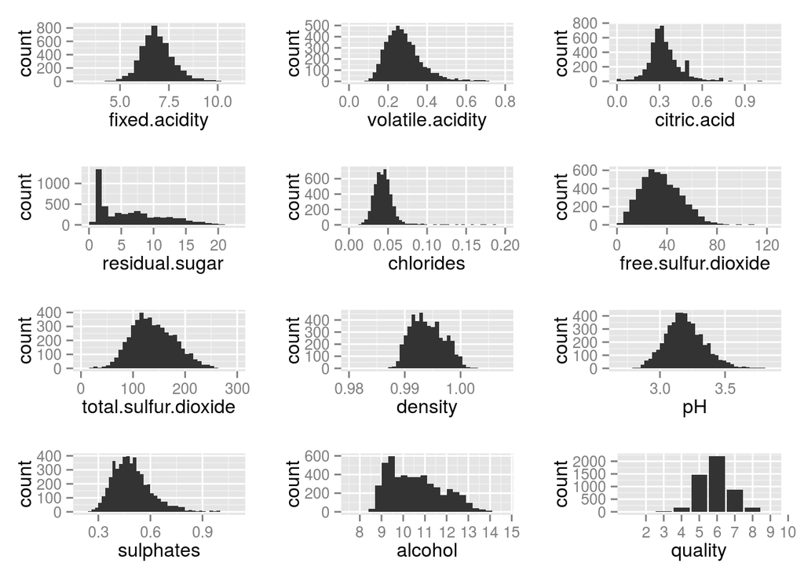

These histograms show that many of the variables have fairly normal distributions, but they have long right tails. However, `residual.sugar` and `alcohol` are both very right skewed.

I think that for wines generally, the distributions of `residual.sugar` and `alcohol` would tend to have different distributions because `residual.sugar` would decrease as `alcohol` increases. Vinho Verde is, however, not a typical wine as it is both highly acidic and low alcohol.

I will now use boxplots to examine the right tails of all of the variables (except for `quality` which has no right tail).

### All Variable Boxplots

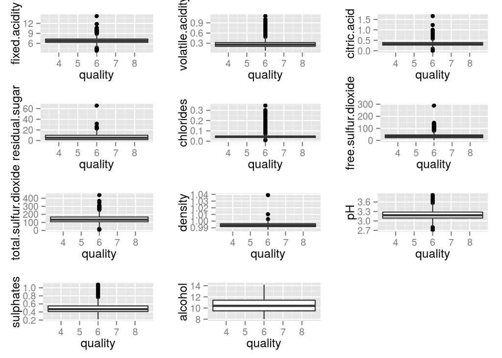

As expected, there are many outliers on the high end of the spectrum for most of the variables.

### Outlier Analysis

I will analyze each variable independently to determine which outliers, if any, should be removed.

#### Fixed Acidity

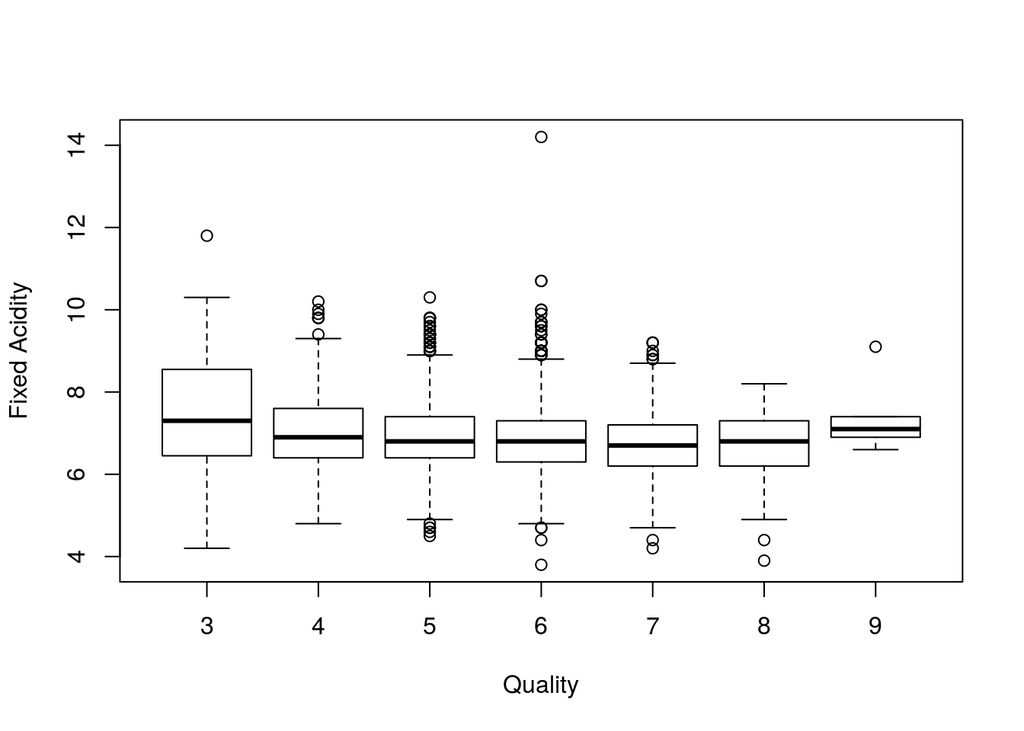

```r
boxplot(fixed.acidity ~ quality, data=wine,
        xlab="Quality", ylab="Fixed Acidity")
```

```r
summary(wine$fixed.acidity)
```

```
##    Min. 1st Qu.  Median    Mean 3rd Qu.    Max.
##   3.800   6.300   6.800   6.855   7.300  14.200
```

```r
quantile(wine$fixed.acidity, c(.999))
```

```
## 99.9%
##  10.3
```

This shows that 99.9% of the observations have fixed.acidity of 10.3 or below.

```r
wine$quality[wine$fixed.acidity > 10.3]
```

```
## [1] 6 6 6 3
```

There are 4 outlier observations. Again, most of them are ranked as having a quality of 6. This is not surprising, because so many observations in the dataset are ranked 6.

I will repeat this process for each of the variables and then remove the outliers at the end.

#### Volatile Acidity

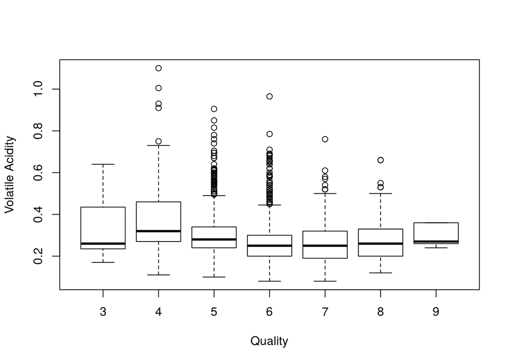

```r
boxplot(volatile.acidity ~ quality, data=wine,
        xlab="Quality", ylab="Volatile Acidity")
```

```r
quantile(wine$volatile.acidity, c(.999))
```

```
##    99.9%
## 0.905515
```

```r
summary(wine$volatile.acidity)
```

```
##    Min. 1st Qu.  Median    Mean 3rd Qu.    Max.
##  0.0800  0.2100  0.2600  0.2782  0.3200  1.1000
```

```r
wine$quality[wine$volatile.acidity > 0.9055]
```

```
## [1] 4 4 4 6 4
```

This time most of the outliers are have the quality 4 which is clear from the boxplot. This is interesting because there are not many observations with quality 4. Because I suspect that acidity may be a potential key factor in predicting bad wines, I am hesitant to conclude that these are actually outliers.

#### Citric Acid.

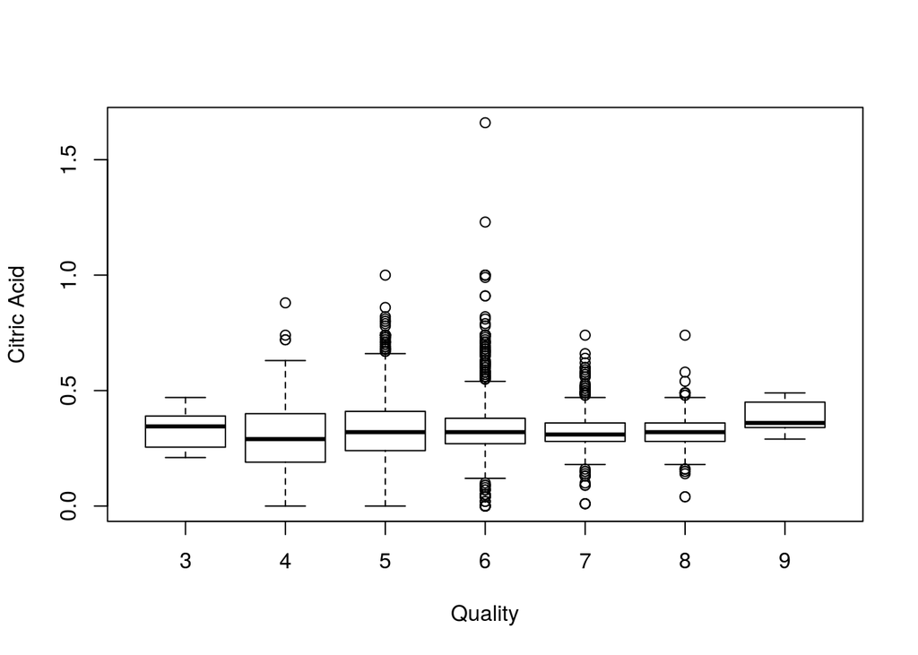

```r
boxplot(citric.acid ~ quality, data=wine,
        xlab="Quality", ylab="Citric Acid")
```

```r
quantile(wine$citric.acid, c(.999))
```

```
## 99.9%
##     1
```

```r
summary(wine$citric.acid)
```

```
##    Min. 1st Qu.  Median    Mean 3rd Qu.    Max.
##  0.0000  0.2700  0.3200  0.3342  0.3900  1.6600
```

```r
wine$quality[wine$citric.acid > 1]
```

```
## [1] 6 6
```

These outliers are both ranked as 6 on quality. The boxplot is interesting because both the quality 3 and the quality 9 wines have no outliers and all of the other ranks do. This could be just chance. It could also be that variation in citric acid is somehow related to middle tier wines.

#### Residual Sugar

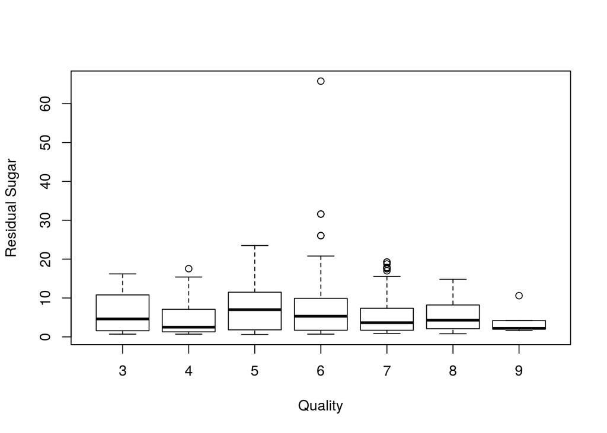

```r
boxplot(residual.sugar ~ quality, data=wine,
        xlab="Quality", ylab="Residual Sugar")
```

```r
quantile(wine$residual.sugar, c(.9999))
```

```
##   99.99%
## 49.05226
```

```r
summary(wine$residual.sugar)
```

```
##    Min. 1st Qu.  Median    Mean 3rd Qu.    Max.
##   0.600   1.700   5.200   6.391   9.900  65.800
```

```r
wine$quality[wine$residual.sugar > 49.05]
```

```
## [1] 6
```

#### Chlorides

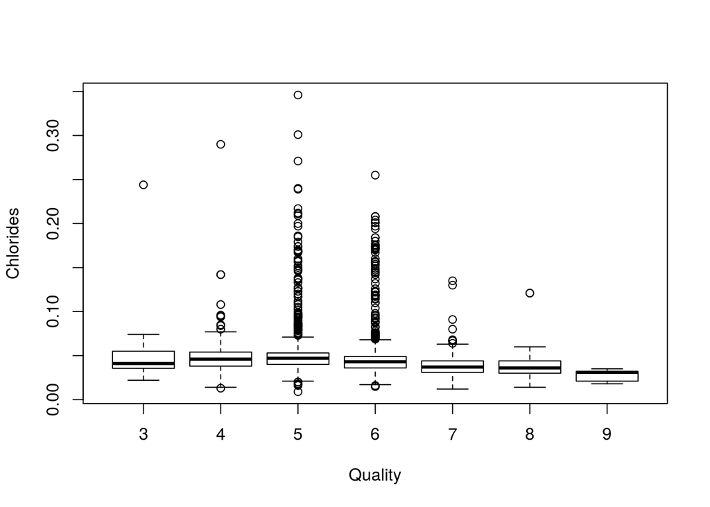

```r
boxplot(chlorides ~ quality, data=wine,
        xlab="Quality", ylab="Chlorides")
```

```r
quantile(wine$chlorides, c(.9999))
```

```
##    99.99%
## 0.3239635
```

```r
summary(wine$chlorides)
```

```
##    Min. 1st Qu.  Median    Mean 3rd Qu.    Max.
## 0.00900 0.03600 0.04300 0.04577 0.05000 0.34600
```

```r
wine$quality[wine$chlorides > 0.245133]
```

```
## [1] 5 4 5 6 5
```

The wines ranked 9 are all very closely distributed and there are no outliers. Also the mean is lower for this group than any other group. It is possible that very low chlorides is indicative of very good wine. It could also be due to the extremely small number of wines that are ranked 9 in quality (5 wines).

#### Free Sulfur Dioxide

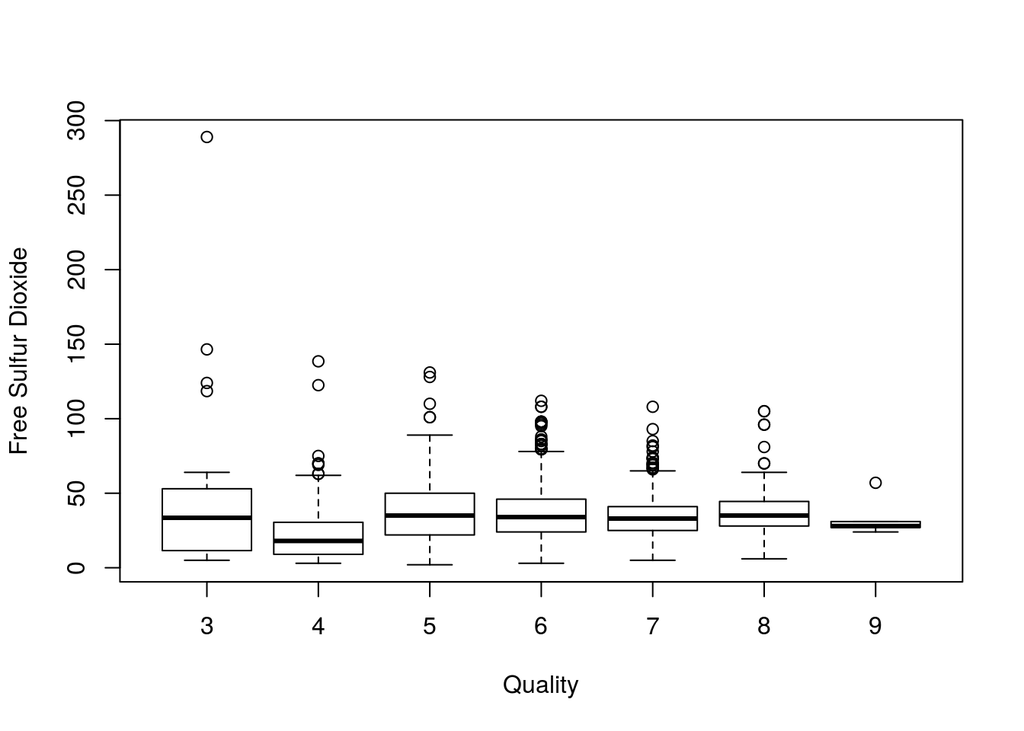

```r
boxplot(free.sulfur.dioxide ~ quality, data=wine,
        xlab="Quality", ylab="Free Sulfur Dioxide")
```

```r
quantile(wine$free.sulfur.dioxide, c(.999))
```

```
##   99.9%
## 124.412
```

```r
summary(wine$free.sulfur.dioxide)
```

```
##    Min. 1st Qu.  Median    Mean 3rd Qu.    Max.
##    2.00   23.00   34.00   35.31   46.00  289.00
```

```r
wine$quality[wine$free.sulfur.dioxide > 124.412]
```

```
## [1] 5 3 5 4 3
```

All quality groups have at least one outlier and the means are fairly similar with the exception of 4. This looks like as the quality improves, the range of variation tends to decrease.

#### Total Sulfur Dioxide

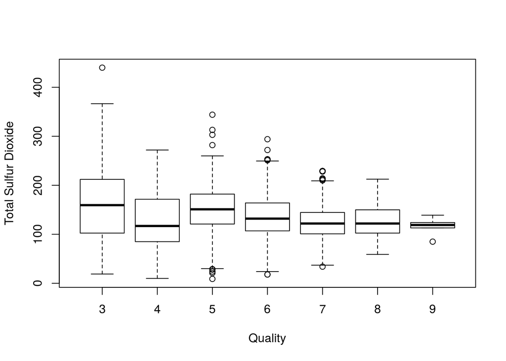

```r
boxplot(total.sulfur.dioxide ~ quality, data=wine,
        xlab="Quality", ylab="Total Sulfur Dioxide")
```

```r
quantile(wine$total.sulfur.dioxide, c(.999))
```

```
##    99.9%
## 303.4635
```

```r
quantile(wine$total.sulfur.dioxide, c(.001))
```

```
##   0.1%
## 20.794
```

```r
summary(wine$total.sulfur.dioxide)
```

```
##    Min. 1st Qu.  Median    Mean 3rd Qu.    Max.
##     9.0   108.0   134.0   138.4   167.0   440.0
```

```r
wine$quality[wine$total.sulfur.dioxide > 303.4635]
```

```
## [1] 5 3 3 5 3
```

```r
wine$quality[wine$total.sulfur.dioxide < 20.794]
```

```
## [1] 3 6 6 5 4
```

The trend mentioned above is also true here; the range of variation tends to decrease with improving wine quality.

#### Density

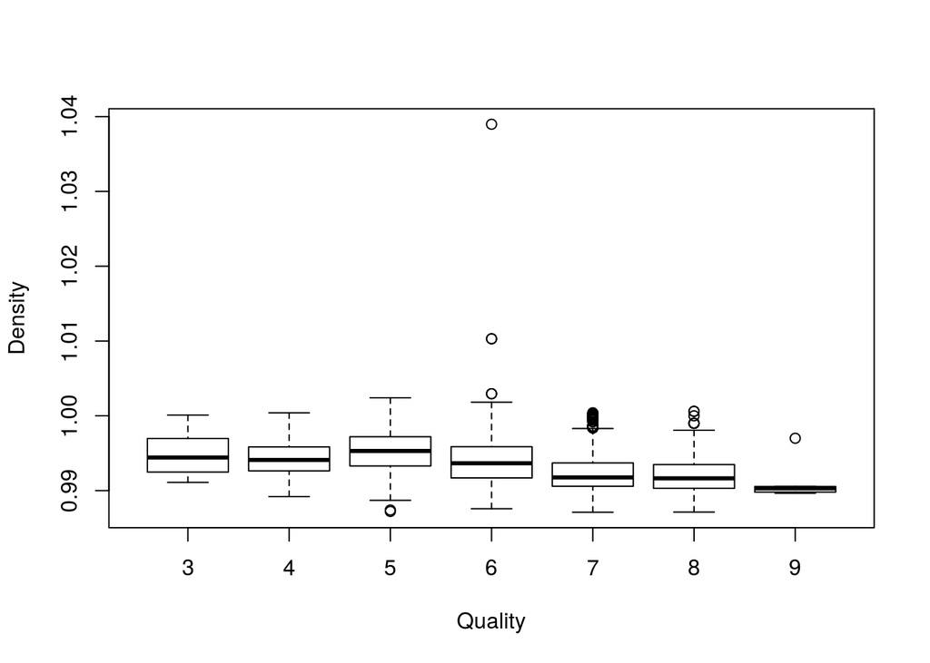

```r
boxplot(density ~ quality, data=wine,
        xlab="Quality", ylab="Density")
```

```r
quantile(wine$density, c(.9999))
```

```
##   99.99%
## 1.024935
```

```r
summary(wine$density)
```

```
##    Min. 1st Qu.  Median    Mean 3rd Qu.    Max.
##  0.9871  0.9917  0.9937  0.9940  0.9961  1.0390
```

```r
wine$quality[wine$density > 1.024935]
```

```
## [1] 6
```

This is also easily an outlier. Given the number of wines that are ranked 6, it seems unlikely that a density of this level is accurate or representative of the group.

#### pH

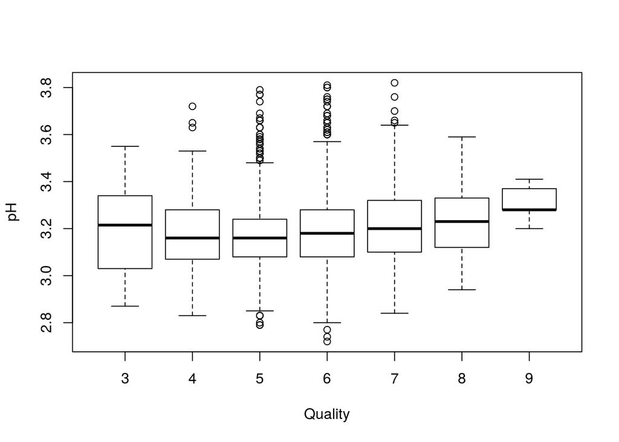

```r
boxplot(pH ~ quality, data=wine,
        xlab="Quality", ylab="pH")
```

```r
quantile(wine$pH, c(.9999))
```

```
##   99.99%
## 3.815103
```

```r
quantile(wine$pH, c(.001))
```

```
## 0.1%
## 2.79
```

```r
summary(wine$pH)
```

```
##    Min. 1st Qu.  Median    Mean 3rd Qu.    Max.
##   2.720   3.090   3.180   3.188   3.280   3.820
```

```r
wine$quality[wine$pH > 3.815103]
```

```
## [1] 7
```

```r
wine$quality[wine$pH < 2.79]
```

```
## [1] 6 6 6
```

Here we see that group 3 has greater dispersion, but no outliers while group 9 shows smaller dispersion.

#### Sulphates

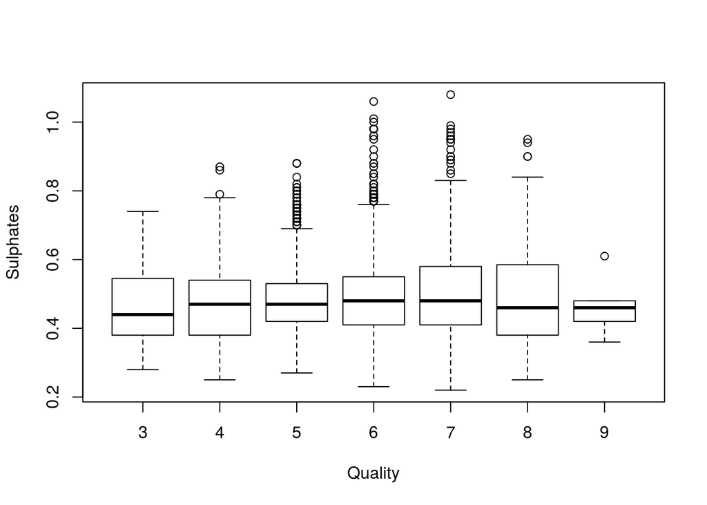

```r
boxplot(sulphates ~ quality, data=wine,
        xlab="Quality", ylab="Sulphates")
```

```r
quantile(wine$sulphates, c(.999))
```

```
##   99.9%
## 0.98103
```

```r
quantile(wine$sulphates, c(.001))
```

```
## 0.1%
## 0.25
```

```r
summary(wine$sulphates)
```

```
##    Min. 1st Qu.  Median    Mean 3rd Qu.    Max.
##  0.2200  0.4100  0.4700  0.4898  0.5500  1.0800
```

```r
wine$quality[wine$sulphates > 0.98103]
```

```
## [1] 6 6 7 6 7
```

```r
wine$quality[wine$sulphates < 0.25]
```

```
## [1] 7 6
```

The means in this plot are all very close together. It is difficult to see from this how sulphates might realte to quality.

#### Alcohol

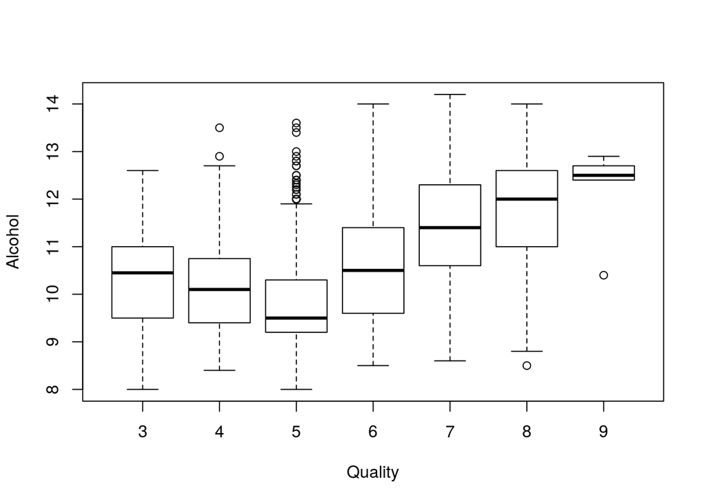

```r
boxplot(alcohol ~ quality, data=wine,
        xlab="Quality", ylab="Alcohol")
```

```r
quantile(wine$alcohol, c(.999))
```

```
## 99.9%
##    14
```

```r
quantile(wine$alcohol, c(.001))
```

```
##   0.1%
## 8.4897
```

```r
summary(wine$alcohol)
```

```
##    Min. 1st Qu.  Median    Mean 3rd Qu.    Max.
##    8.00    9.50   10.40   10.51   11.40   14.20
```

```r
wine$quality[wine$alcohol > 14]
```

```
## [1] 7 7
```

```r
wine$quality[wine$alcohol < 8.48]
```

```
## [1] 5 3 5 5 4
```

There seems to be a relationship between alcohol and quality. I will analyze this further in the next section.

### Removing Outliers

Now that I have finished the analysis of each variable I will look at the cases I have tagged as outliers.

```r
outliers = wine[wine$fixed.acidity >= 10.3 |
                wine$volatile.acidity >= 0.90552 |
                wine$citric.acid >= 1 |
                wine$residual.sugar >= 49.05 |
                wine$chlorides >= 0.245 |
                wine$free.sulfur.dioxide >= 124.412 |
                wine$total.sulfur.dioxide >= 303.46 |
                wine$total.sulfur.dioxide <= 20.794 |
                wine$density >= 1.024935 |
                wine$pH >= 3.81510 |
                wine$sulphates >= 0.98103,]

table(outliers$quality)
```

```
##
##  3  4  5  6  7
##  6  7  9 16  3
```

```r
table(wine$quality)
```

```
##
##    3    4    5    6    7    8    9
##   20  163 1457 2198  880  175    5
```

Looking at the tables for quality, we can see that there are 20 cases with a quality of 3. The outliers table indicates that 6 of them have been flagged. I will not exclude these from the analysis because I would be removing 30% of the wines with quality of 3 and I feel that this would impact further analysis of the lower quality wines.

Similarly, I am hesitant to remove the 7 observations for quality 4 which have been tagged as outliers. This represents 4% of all quality 4 wines which may be enough to skew the results of later analysis. Additionally, I am interested that so many of the lowest quality wines turned up as outliers while none of the highly ranked wines (ranked 8 or 9) did. For these reasons, I will not remove these right now.

I am comfortable removing the other outliers because they make up such a small portion of their respective quality rankings.

```r
not_outliers = outliers[outliers$quality <= 4,]
```

Now I will remove the remaining outliers from the wine data frame and plot the resulting distributions.

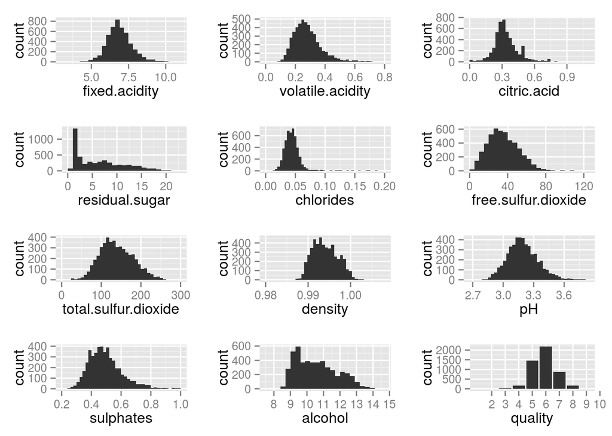

We can see from this plot that the distributions are slightly more normal, but the removal of the outliers has not materially impacted the distributions.

# Bivariate Analysis

I begin this section by plotting all of the variables in a table with the `ggpairs` function.

### Plot ggpairs

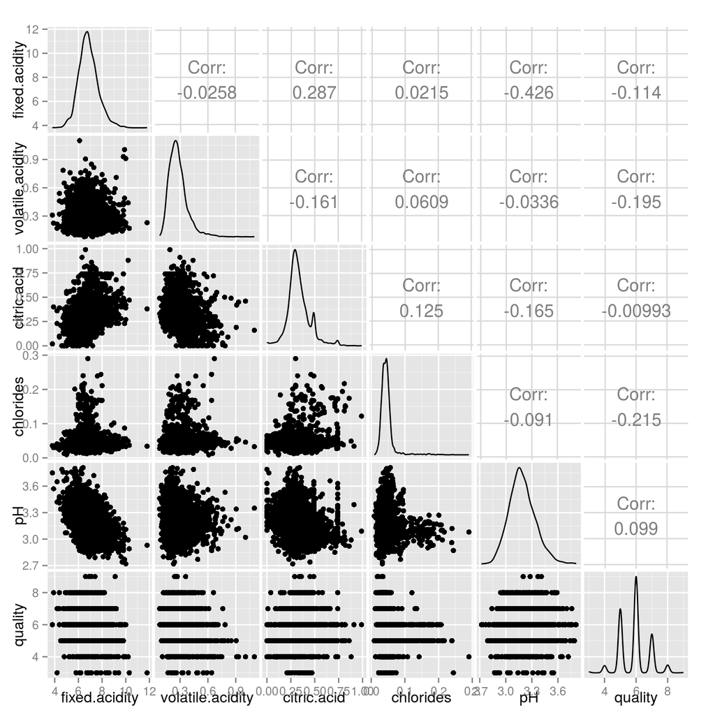

This plot contains half of the variables in the dataset and `quality`. It shows that `quality` is only modestly correlated with `chlorides` and `volatile.acidity`, and both correlations are negative. The other variables have extremely low correlation with quality.

This plot also shows that `fixed.acidity` and `pH` are negatively correlated which makes intuitive sense.

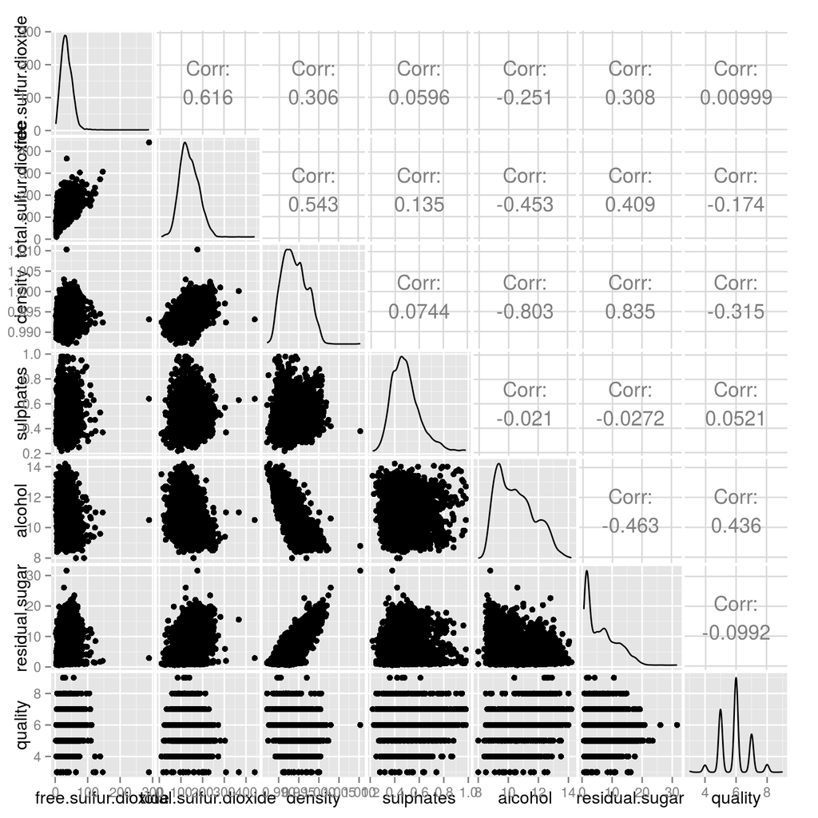

This plot contains the second half of the variables and `quality`. Here we can see that `alcohol` is the variable most highly correlated with `quality` at 0.436. The variable next most correlated with `quality` is `density` at -0.315. This is not surprising because of the high correlation between `density` and `alcohol` (-0.803).

In all, only 3 sets of variables are very correlated with each other.

- `total.sulfur.dioxide` with `free.sulfur.dioxide`: 0.616
- `density` and `residual.sugar`: 0.835
- `alcohol` and `density`: -0.803

Considering both of these plots it appears that the variables least correlated with `quality` are `free.sulfur.dioxide` and `citric.acid`.

### Create Good Wine and Bad Wine Dataframes

I am going to subset the orginal data into good wines and bad wines in order to determine which variables are correlated to good wines versus bad wines.

```r
bad_wine = subset(wine, wine$quality < 5)
good_wine = subset(wine, wine$quality > 7)
```

Unfortunately, these subsets are fairly small (about 180 observations each). But, I would like to see if I can discern some differences in the correlations between variables with respect to the good and bad wine data frames.

### Create Correlations Dataframe

```r
corrs = c(names(wine))
bad = NULL
good = NULL

# Add correlations to vectors
for (i in 1:12 ) {
  bad[i] = cor(bad_wine[corrs[i]], bad_wine$quality)
}

for (i in 1:12 ) {
  good[i] = cor(good_wine[corrs[i]], good_wine$quality)
}

# Join vectors in a dataframe.
corrs = data.frame(bad, good)
rownames(corrs) <- c(names(wine))

# Remove quality variable
corrs = corrs[-c(12), ]

corrs
```

```
##                               bad        good
## fixed.acidity        -0.125623380  0.15134492
## volatile.acidity      0.088022382  0.03175293
## citric.acid          -0.063249741  0.11440211
## residual.sugar       -0.127686572 -0.06017763
## chlorides            -0.045804258 -0.13677883
## free.sulfur.dioxide  -0.302405803 -0.03395987
## total.sulfur.dioxide -0.227325381 -0.05120006
## density              -0.075883061 -0.04582037
## pH                   -0.008563154  0.09723198
## sulphates             0.004340483 -0.02287916
## alcohol              -0.058623334  0.07034801
```

This data frame shows the correlations between each variable and `quality`. I will examine the strongest correlations.

### Consider Reliability of Correlations

I will run `cor.test` to determine if we can rely on the strength of the strongest correlations

```r
cor.test(bad_wine$free.sulfur.dioxide, bad_wine$quality, method = 'pearson')
```

```
##
##  Pearson's product-moment correlation
##
## data:  bad_wine$free.sulfur.dioxide and bad_wine$quality
## t = -4.2683, df = 181, p-value = 3.173e-05
## alternative hypothesis: true correlation is not equal to 0
## 95 percent confidence interval:
##  -0.4286589 -0.1645681
## sample estimates:
##        cor
## -0.3024058
```

This is the test for the correlation between `free.sulfur.dioxide` and bad wine quality.

```r
cor.test(bad_wine$total.sulfur.dioxide, bad_wine$quality, method = 'pearson')
```

```
##
##  Pearson's product-moment correlation
##
## data:  bad_wine$total.sulfur.dioxide and bad_wine$quality
## t = -3.1406, df = 181, p-value = 0.00197
## alternative hypothesis: true correlation is not equal to 0
## 95 percent confidence interval:
##  -0.36049470 -0.08507405
## sample estimates:
##        cor
## -0.2273254
```

This is the correlation between `total.sulfur.dioxide` and bad wine quality.

```r
cor.test(good_wine$fixed.acidity, good_wine$quality, method = 'pearson')
```

```
##
##  Pearson's product-moment correlation
##
## data:  good_wine$fixed.acidity and good_wine$quality
## t = 2.0427, df = 178, p-value = 0.04255
## alternative hypothesis: true correlation is not equal to 0
## 95 percent confidence interval:
##  0.005196635 0.291162990
## sample estimates:
##       cor
## 0.1513449
```

This the is correlation test for `fixed.acidity` and good wine quality.

These correlation tests indicate that the confidence intervals for these variables do not include 0, so we can be confident that there is a correlation in the direction indicated. These are, however, all low correlations.

### Differences in Correlations Between Good and Bad Wines

While these are all weak correlations, what is interesting is the change in correlation given the quality of the wine.

```r
corrs = addColumn(corrs, corrs$bad - corrs$good)
corrs$diff = corrs$vector
corrs$vector = NULL

corrs[with(corrs, order(diff)), ]
```

```
##                               bad        good        diff
## fixed.acidity        -0.125623380  0.15134492 -0.27696830
## free.sulfur.dioxide  -0.302405803 -0.03395987 -0.26844594
## citric.acid          -0.063249741  0.11440211 -0.17765185
## total.sulfur.dioxide -0.227325381 -0.05120006 -0.17612532
## alcohol              -0.058623334  0.07034801 -0.12897134
## pH                   -0.008563154  0.09723198 -0.10579514
## residual.sugar       -0.127686572 -0.06017763 -0.06750894
## density              -0.075883061 -0.04582037 -0.03006270
## sulphates             0.004340483 -0.02287916  0.02721964
## volatile.acidity      0.088022382  0.03175293  0.05626945
## chlorides            -0.045804258 -0.13677883  0.09097457
```

This shows that `fixed.acidity` and `free.sulfur.dioxide` are also the largest differences in correlation between the good and bad wines. Therefore, I will focus mostly on these two variables.

### Relationship Between Free Sulfur Dioxide and Total Sulfur Dioxide

The description of the variables indicates that that `free.sulfur.dioxide` and `total.sulfur.dioxide` are related and that `free.sulfur.dioxide` “prevents microbial growth and the oxidation of wine.” The description for `total.sulfur.dioxide` further explains that concentrations of free SO2 over 50 ppm affects the taste and smell of wine. This explains the correlation of 0.616 between the two variables with respect to all wines mentioned above.

I will determine the correlation between these two variables with respect to bad wines.

```r
cor.test(bad_wine$free.sulfur.dioxide, bad_wine$total.sulfur.dioxide, method = 'pearson')
```

```
##
##  Pearson's product-moment correlation
##
## data:  bad_wine$free.sulfur.dioxide and bad_wine$total.sulfur.dioxide
## t = 13.4861, df = 181, p-value < 2.2e-16
## alternative hypothesis: true correlation is not equal to 0
## 95 percent confidence interval:
##  0.6273231 0.7735729
## sample estimates:
##       cor
## 0.7079575
```

### Free Sulfur Dioxide Frequency Polygons

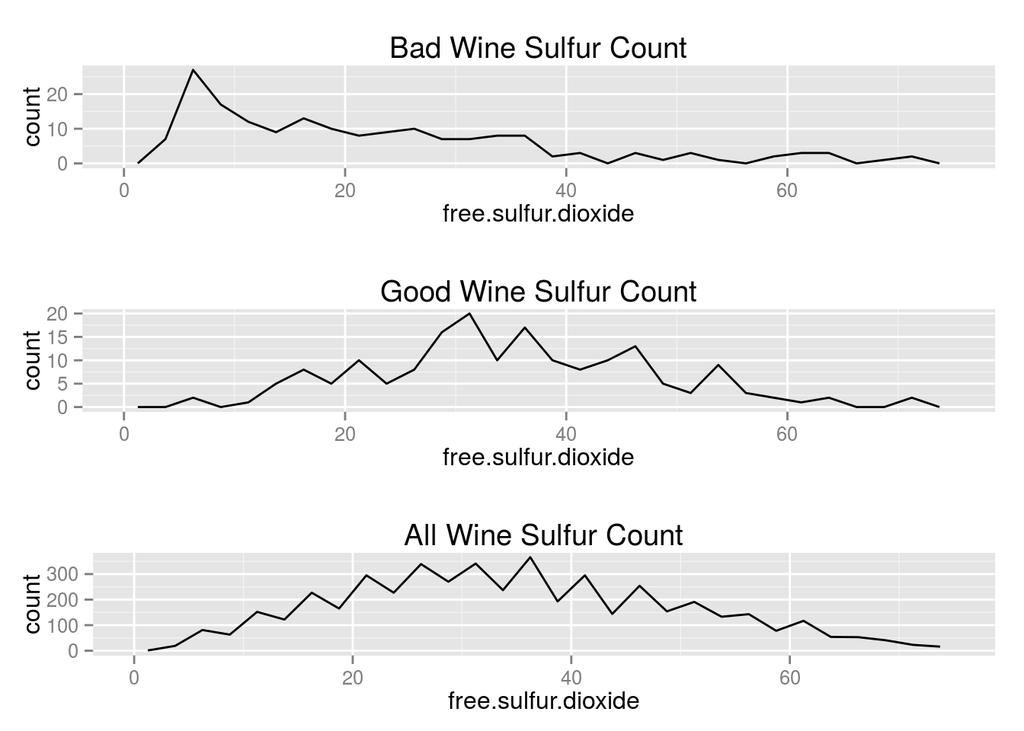

```r
p1 = ggplot(aes(x =free.sulfur.dioxide), data = bad_wine) +
  geom_freqpoly() +
  ggtitle("Bad Wine Sulfur Count") +
  xlim(c(0, 75))

p2 = ggplot(aes(x =free.sulfur.dioxide), data = good_wine) +
  geom_freqpoly() +
  ggtitle("Good Wine Sulfur Count") +
  xlim(c(0, 75))

p3 = ggplot(aes(x =free.sulfur.dioxide), data = wine) +
  geom_freqpoly() +
  ggtitle("All Wine Sulfur Count") +
  xlim(c(0, 75))

grid.arrange(p1, p2, p3, ncol= 1)
```

These plots make clear that the distribution of `free.sulfur.dioxide` is very different with respect to bad wines. Generally, the bad wines have much lower sulfur counts. The distributions of good wines and all wines are relatively similar.

### Free Sulfur Dioxide Summaries

Here is another view of the differences between the groups.

```r
summary(bad_wine$free.sulfur.dioxide)
```

```
##    Min. 1st Qu.  Median    Mean 3rd Qu.    Max.
##    3.00    9.00   18.00   26.63   33.50  289.00
```

```r
summary(good_wine$free.sulfur.dioxide)
```

```
##    Min. 1st Qu.  Median    Mean 3rd Qu.    Max.
##    6.00   28.00   34.50   36.63   44.25  105.00
```

```r
summary(wine$free.sulfur.dioxide)
```

```
##    Min. 1st Qu.  Median    Mean 3rd Qu.    Max.
##    2.00   23.00   34.00   35.28   46.00  289.00
```

These summaries further demonstrate the difference in measures of `free.sulfur.dioxide` with respect to bad wines and all other wines. Additionally, it appears that one of the outliers I chose to leave in the dataset could be problematic here.

```r
bad_wine[bad_wine$free.sulfur.dioxide == 289.0, ]
```

```
##      fixed.acidity volatile.acidity citric.acid residual.sugar chlorides
## 4746           6.1             0.26        0.25            2.9     0.047
##      free.sulfur.dioxide total.sulfur.dioxide density   pH sulphates
## 4746                 289                  440 0.99314 3.44      0.64
##      alcohol quality
## 4746    10.5       3
```

```r
wine[wine$free.sulfur.dioxide > 140.0, ]
```

```
##      fixed.acidity volatile.acidity citric.acid residual.sugar chlorides
## 1932           7.1             0.49        0.22            2.0     0.047
## 4746           6.1             0.26        0.25            2.9     0.047
##      free.sulfur.dioxide total.sulfur.dioxide density   pH sulphates
## 1932               146.5                307.5 0.99240 3.24      0.37
## 4746               289.0                440.0 0.99314 3.44      0.64
##      alcohol quality
## 1932    11.0       3
## 4746    10.5       3
```

The next largest `free.sulfur.dioxide` value is 146.5. I am going to remove this value from the bad_wines dataframe as well as the wines dataframe and see how that affects the correlation. This value is so far above the typical values, that I feel its removal would improve the analysis.

### Remove Outlier

```r
# Remove the outlier from the bad data frame.
which(bad_wine$free.sulfur.dioxide == 289.0)
```

```
## [1] 183
```

```r
bad_wine = bad_wine[-c(183), ]

# Remove the same observation from the main data frame.
which(wine$free.sulfur.dioxide == 289.0)
```

```
## [1] 4870
```

```r
wine = wine[-c(4870), ]
```

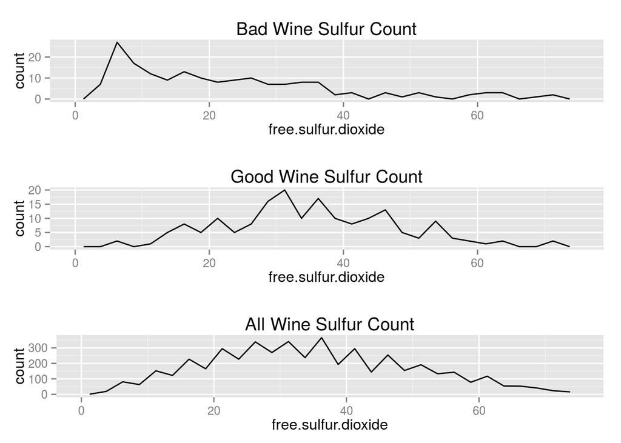

```r
summary(bad_wine$free.sulfur.dioxide)
```

```
##    Min. 1st Qu.  Median    Mean 3rd Qu.    Max.
##    3.00    9.00   18.00   25.19   32.75  146.50
```

```r
summary(wine$free.sulfur.dioxide)
```

```
##    Min. 1st Qu.  Median    Mean 3rd Qu.    Max.
##    2.00   23.00   34.00   35.22   46.00  146.50
```

```r
summary(good_wine$free.sulfur.dioxide)
```

```
##    Min. 1st Qu.  Median    Mean 3rd Qu.    Max.
##    6.00   28.00   34.50   36.63   44.25  105.00
```

```r
cor.test(bad_wine$free.sulfur.dioxide, bad_wine$quality, method = 'pearson')
```

```
##
##  Pearson's product-moment correlation
##
## data:  bad_wine$free.sulfur.dioxide and bad_wine$quality
## t = -3.0666, df = 180, p-value = 0.002499
## alternative hypothesis: true correlation is not equal to 0
## 95 percent confidence interval:
##  -0.35671575 -0.07995751
## sample estimates:
##        cor
## -0.2228216
```

In this process, I removed the observation where `free.sulfur.dioxide` was 289. Removing the outlier made `free.sulfur.dioxide` less negatively correlated with quality (correlation went from -0.3024 to -0.2228)

The mean and median `free.sulfur.dioxide` for the good wines and all wines are higher than the 3rd Quartile value for the bad wines. It is possible that the bad wines have insufficient amounts of `free.sulfur.dioxide` to prevent oxidation which could affect the quality of the wine.

It is interesting to recall that I earlier found that, with respect to the entire data set, the correlation between `free.sulfur.dioxide` and `quality` was 0.00816, the lowest correlation of any variable in the dataset with `quality`. Once we split the data, this variable has the highest correlation with `quality` for the bad wines.

### Fixed Acidity Difference in Correlation

Now I will examine `fixed.acidity` as it relates to quality. This variable showed a large difference in correlation to quality when separating out the good wines.

```r
cor.test(wine$fixed.acidity, wine$quality, method = 'pearson')
```

```
##
##  Pearson's product-moment correlation
##
## data:  wine$fixed.acidity and wine$quality
## t = -8.0843, df = 4867, p-value = 7.824e-16
## alternative hypothesis: true correlation is not equal to 0
## 95 percent confidence interval:
##  -0.14273841 -0.08730274
## sample estimates:
##        cor
## -0.1151102
```

```r
cor.test(good_wine$fixed.acidity, good_wine$quality, method = 'pearson')
```

```
##
##  Pearson's product-moment correlation
##
## data:  good_wine$fixed.acidity and good_wine$quality
## t = 2.0427, df = 178, p-value = 0.04255
## alternative hypothesis: true correlation is not equal to 0
## 95 percent confidence interval:
##  0.005196635 0.291162990
## sample estimates:
##       cor
## 0.1513449
```

The correlation went from -0.11 with the whole dataset to 0.15 in the good_wine dataframe. While these on their own show only very slight correlation, the change in direction may prove to be significant. Additionally, the confidence intervals in these correlation tests show that there is indeed a change in direction of the correlation.

### Fixed Acidity Histograms

Now I will plot the histograms of this variable with respect to each group.

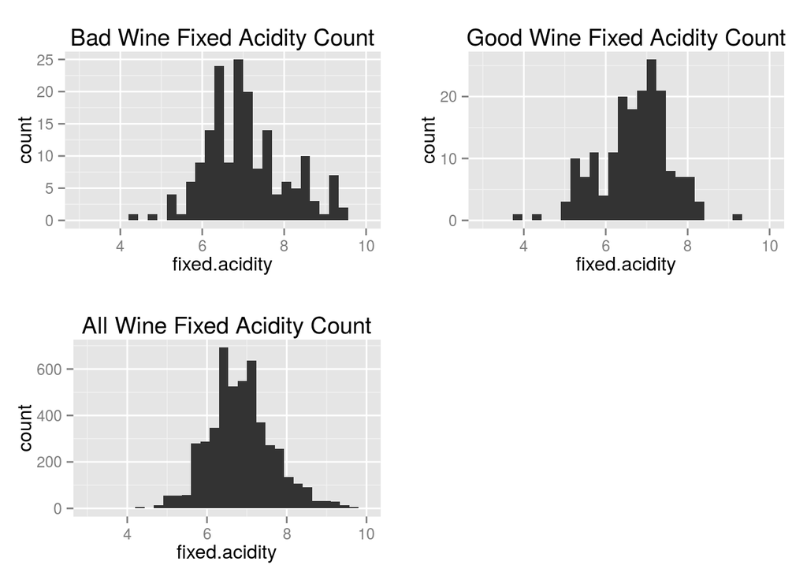

The difference between these plots is very slight, but appears that `fixed.acidity` is very slightly higher on average in the good wines and there is less variance in the good wines. It appears that the bad wines have a less uniform distribution, and the good wines are more normally distributed. The plot for all wines is the most uniform.

Maybe the summaries will illuminate the differences.

### Fixed Acidity Summaries

```r
summary(bad_wine$fixed.acidity)
```

```
##    Min. 1st Qu.  Median    Mean 3rd Qu.    Max.
##   4.200   6.400   6.900   7.187   7.675  11.800
```

```r
summary(good_wine$fixed.acidity)
```

```
##    Min. 1st Qu.  Median    Mean 3rd Qu.    Max.
##   3.900   6.200   6.800   6.678   7.300   9.100
```

```r
summary(wine$fixed.acidity)
```

```
##    Min. 1st Qu.  Median    Mean 3rd Qu.    Max.
##   3.800   6.300   6.800   6.848   7.300  11.800
```

The summaries indicate that good wines have a smaller range of the `fixed.acidity` variable than either the bad wines or the whole dataset. The medians and means are nearly the same. Also, it appears I was wrong in thinking that the good wines had higher `fixed.acidity` on average. The summaries clarify that the opposite is true.

### Density and Alcohol Plot

As mentioned earlier, `density` and `alcohol` are the most highly correlated variables in the dataset.

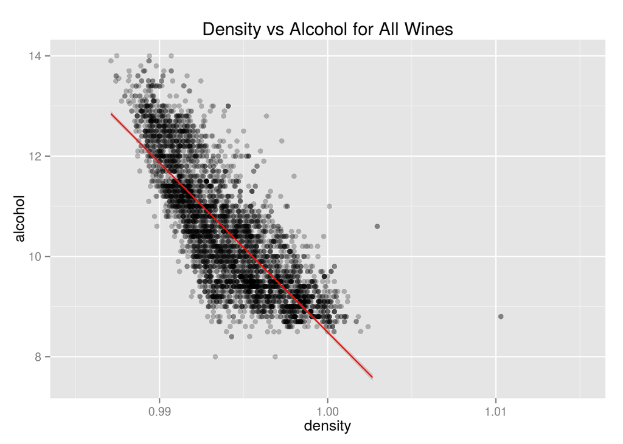

```r
ggplot(aes(x=density, y=alcohol), data = wine) +
  geom_jitter(alpha=1/4) +
  xlim(c(0.985, 1.015)) +
  ylim(c(7.5, 14.0)) +
  geom_smooth(method = 'lm', color='red') +
  ggtitle("Density vs Alcohol for All Wines")
```

```r
cor(wine$density, wine$alcohol)
```

```
## [1] -0.8033696
```

This graph shows that generally, the more alcohol there is in the wine, the lower the density of the wine. These two variables have a strong negative correlation, `-0.803`. The linear model line is not a great fit, but it succeeds in capturing the general trend.

Perhaps a log10 transformation would fit this better.

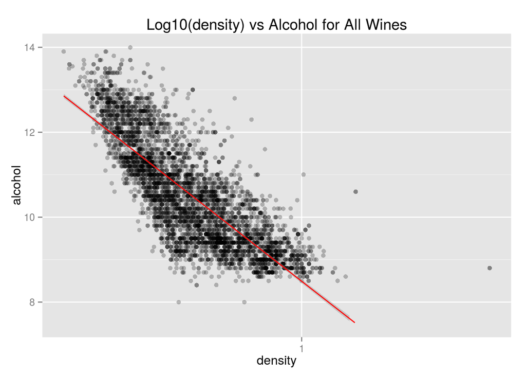

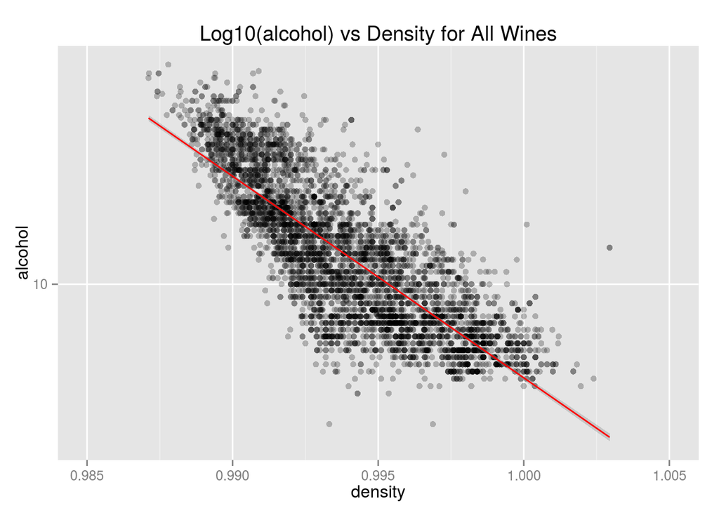

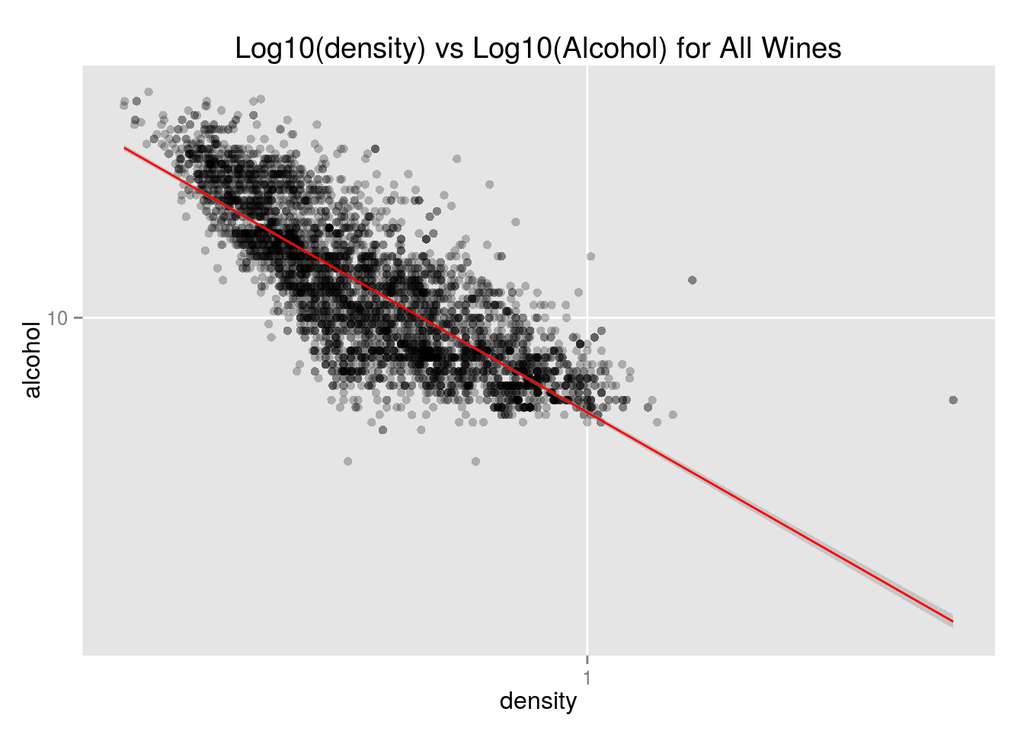

None of these log10 transformations are great models either. However, the last two do a slightly better job with regards to the higher alcohol portion of the plot.

### Fixed Acidity and Alcohol

Now I will plot `fixed.acidity` against `alcohol` and return to the good and bad wine dataframes.

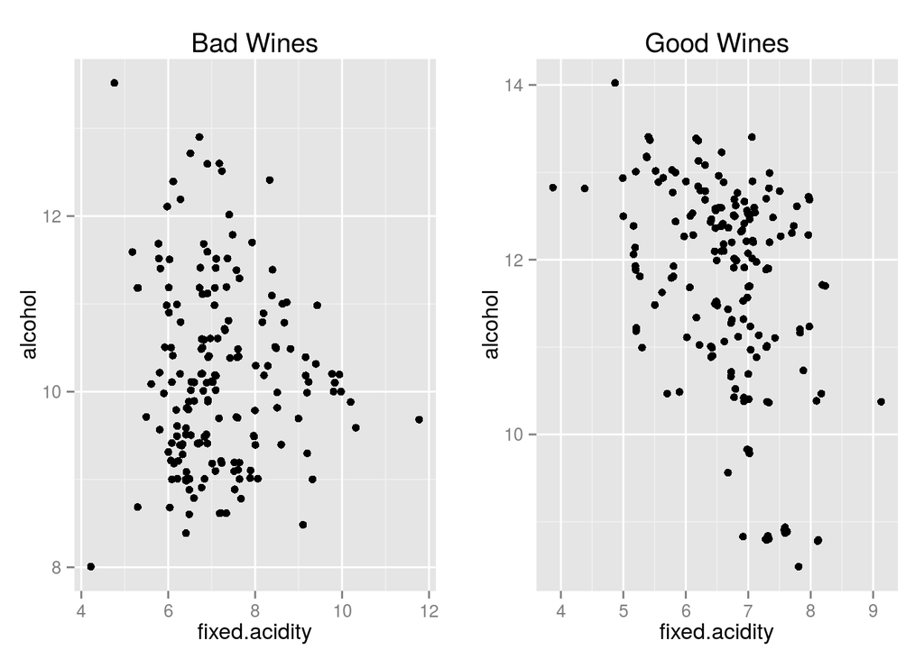

These plots indicate that there are differences between the two groups. Unfortunately, the plots axes are different from one another which makes a comparison very difficult.

I would like to add them to the same plot and use color to highlight the differences.

# Multivariate Analysis

Here I will further explore the relationships that I explored in the last section.

### Remove Average Wines

First I create a dataframe with just the best and worst wines and add a column called `high_quality` which indicates if the wine is ranked either 8 or 9 on the quality scale. Therefore, a value of `FALSE` for this variable indicates that the wine is ranked 3 or 4.

```r
good_and_bad = subset(wine, wine$quality > 7 | wine$quality < 5)

good_and_bad = addColumn(good_and_bad, good_and_bad$quality > 7)
good_and_bad$high_quality = good_and_bad$vector
```

### Alcohol and Density

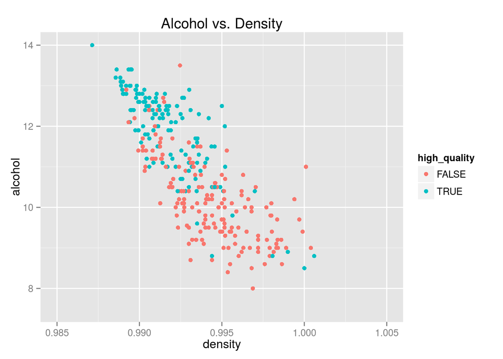

```r
ggplot(aes(y=alcohol, x=density), data = good_and_bad) +
  xlim(c(0.985, 1.005)) +
  geom_point(aes(color=high_quality, group=high_quality)) +
  ylim(c(7.5, 14.0)) +
  ggtitle("Alcohol vs. Density")
```

This plot highlights the differences in alcohol content and density in the top ranked wines and the lowest ranked wines. Generally, high quality wines have higher alcohol content and lower density.

However, there are many observations which do not follow this general trend. Because alcohol and density are highly correlated, perhaps there is another variable that would be more useful.

### Alcohol and Fixed Acidity

I will try `fixed.acidity` because this variable was more highly correlated with high quality wines.

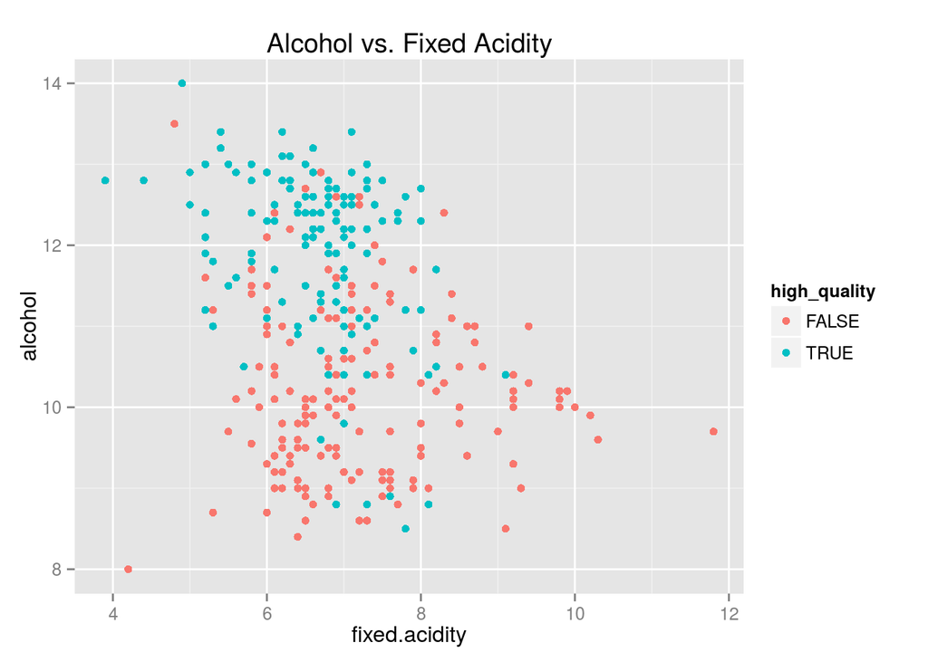

```r
ggplot(aes(y=alcohol, x=fixed.acidity), data = good_and_bad) +
  #xlim(c(0.985, 1.005)) +
  geom_point(aes(color=high_quality, group=high_quality)) +
  #ylim(c(7.5, 14.0)) +
  ggtitle("Alcohol vs. Fixed Acidity")
```

There is a lot of variance in this plot, much more than in the last one. This is likely because there is low correlation between `alcohol` and `fixed acidity`. However, it is clear from this plot that the highest ranked wines have higher alcohol and lower acidity. This is consistent with the information reported in the first section of this analysis.

```r
cor.test(wine$fixed.acidity, wine$alcohol, method = 'pearson')
```

```
##
##  Pearson's product-moment correlation
##
## data:  wine$fixed.acidity and wine$alcohol
## t = -8.5366, df = 4867, p-value < 2.2e-16
## alternative hypothesis: true correlation is not equal to 0
## 95 percent confidence interval:
##  -0.14903926 -0.09368789
## sample estimates:
##       cor
## -0.121458
```

This verifies that there is low correlation between `alcohol` and `fixed.acidity`.

### Free Sulfur to Fixed Sulfur Ratio

I would like to explore the relationship between `free.sulfur.dioxide` and `total.sulfur.dioxide` as it relates to wine quality.

First I need to create a ratio of the two variables.

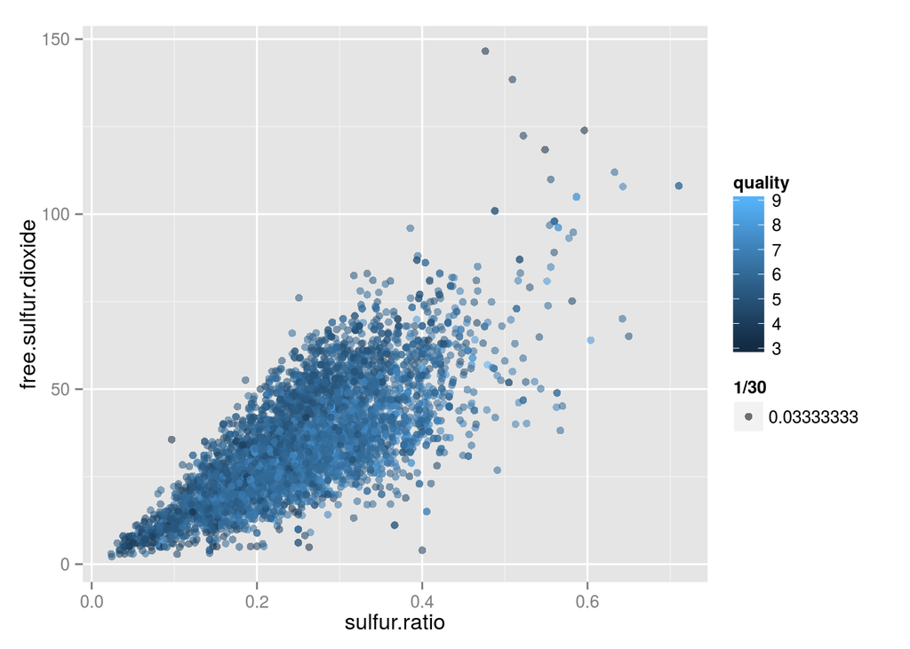

```r
good_and_bad$sulfur.ratio = good_and_bad$free.sulfur.dioxide /
  good_and_bad$total.sulfur.dioxide
wine$sulfur.ratio = wine$free.sulfur.dioxide /
  wine$total.sulfur.dioxide

ggplot(aes(x=sulfur.ratio, y=free.sulfur.dioxide), data=wine) +
  geom_jitter(aes(color = quality, alpha = 1/30))
```

That is prety linear which is to be expected. The y-axis variable is the numerator in the calculation of the x-axis variable.

Now I will add a new variable `rating` to the wine dataframe that places good bad and average wines into corresponding buckets and plot various variables.

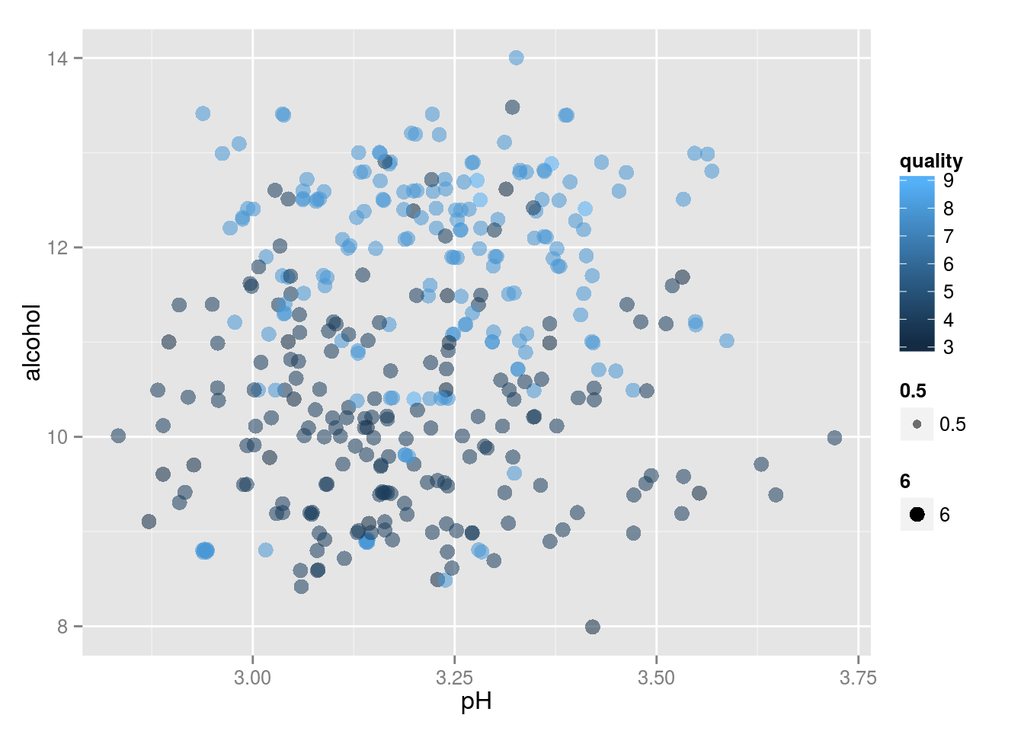

This plot demonstrates again that higher quality wines tend to have higher alcohol content. It explains less of the variation in the pH variable between quality levels, except that higher quality wines have less varied pH levels.

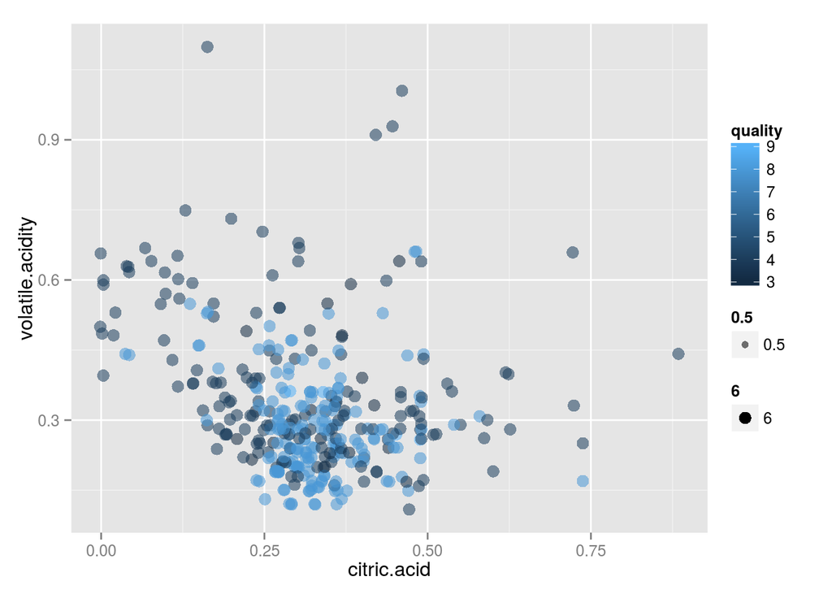

This plot shows that high quality wines also tend to be more clustered in the lower range of `volatile.acid` while in the lower-middle range of `citric acid`. The lower quality wines again show greater dispersion.

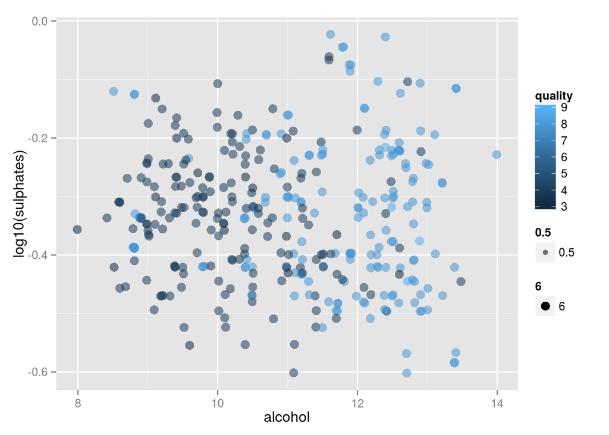

Finally, this plot approximates a kind of east/west divide based on `alcohol` content. The log10(sulphates) appears to have little or no relationship to th quality of wines.

# Final Plots

### Plot 1

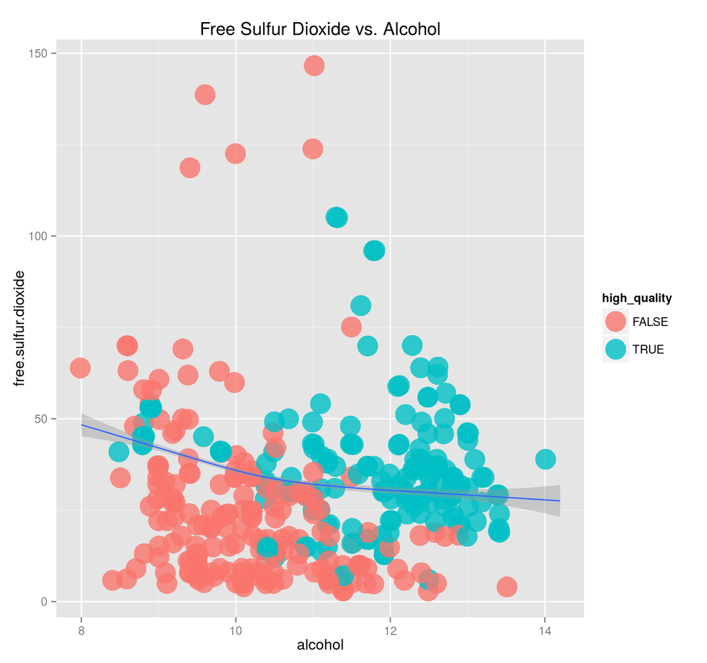

This plot shows two of the largest predictors of `quality` that I found, `alcohol` and `free.sulfur.dioxide`. Only the worst and best wines are actually plotted here, those ranked 3 and 4 are shown in pink while and the wines ranked 8 and 9 are shown in turquoise.

The bad wines typically have lower `free.sulfur.dioxide`, but with more outliers and variation.

The line in the chart represents the conditional mean for the entire dataset. This line is heavily influenced by the majority of the wines in the dataset which are ranked 5 or 6 in `quality` and have `free.sulfur.dioxide` counts more in line with the high quality wines. This line indicates that as `alcohol` increases, `free.sulfur.dioxide` tends to decrease slightly.